# team_04_tidyverse.qmd

Author

Ashsyahid, Owen, Sherwyn, Xuan Yu, Nigel

Published

July 9, 2024

# Task 1: Converting EPL Football Results into a League Table

## 1.1 Generate a League Table from the EPL Results

```r
epl_results <- read_csv("epl/epl_results.csv")
epl_teams <- read_csv("epl/epl_teams.csv")
```

```r
# Prepare the results data
epl_results_long <- epl_results |>
  pivot_longer(cols = -home_team, names_to = "away_team", values_to = "result") |>
  separate(result, into = c("home_goals", "away_goals"), sep = "-", convert = TRUE) |>
  filter(!is.na(home_goals))
```

```r
# Calculate home team statistics
home_stats <- epl_results_long |>
  group_by(home_team) |>
  summarize(
    points_home = sum(if_else(home_goals > away_goals, 3, if_else(home_goals == away_goals, 1, 0))),
    goals_for_home = sum(home_goals),
    goals_against_home = sum(away_goals)
  )
```

```r
# Calculate away team statistics
away_stats <- epl_results_long |>
  group_by(away_team) |>
  summarize(
    points_away = sum(if_else(away_goals > home_goals, 3, if_else(away_goals == home_goals, 1, 0))),
    goals_for_away = sum(away_goals),
    goals_against_away = sum(home_goals)
  )
```

```r
# Combine home and away statistics
team_stats <- home_stats |>
  rename(team = home_team) |>
  full_join(away_stats, by = c("team" = "away_team")) |>
  mutate(
    points = points_home + points_away,
    goals_for = goals_for_home + goals_for_away,
    goals_against = goals_against_home + goals_against_away,
    goal_diff = goals_for - goals_against
  ) |>
  select(team, points, goal_diff, goals_for)
```

```r
# Add full team names
league_table <- team_stats |>
  left_join(epl_teams, by = c("team" = "abbr")) |>
  select(team = name, points, goal_diff, goals_for)
```

```r
# Rank the teams
league_table <- league_table |>
  arrange(desc(points), desc(goal_diff), desc(goals_for)) |>
  mutate(rank = row_number()) |>
  select(rank, team, points, goal_diff, goals_for)
```

```r
# Display the league table
league_table
```

```
# A tibble: 20 × 5
    rank team                    points goal_diff goals_for
   <int> <chr>                    <dbl>     <int>     <int>
 1     1 Liverpool                   99        52        85
 2     2 Manchester City             81        67       102
 3     3 Manchester United           66        30        66
 4     4 Chelsea                     66        15        69
 5     5 Leicester City              62        26        67
 6     6 Tottenham Hotspur           59        14        61
 7     7 Wolverhampton Wanderers     59        11        51
 8     8 Arsenal                     56         8        56
 9     9 Sheffield United            54         0        39
10    10 Burnley                     54        -7        43
11    11 Southampton                 52        -9        51
12    12 Everton                     49       -12        44
13    13 Newcastle United            44       -20        38
14    14 Crystal Palace              43       -19        31
15    15 Brighton & Hove Albion      41       -15        39
16    16 West Ham United             39       -13        49
17    17 Aston Villa                 35       -26        41
18    18 Bournemouth                 34       -25        40
19    19 Watford                     34       -28        36
20    20 Norwich City                21       -49        26
```

…

## 1.2 Improve Visualization Using `gt` Functions and Discuss rationale

```r
# Create a gt table
gt_table <- league_table |>
  gt() |>
  tab_header(
    title = md("**English Premier League Table**"),
    subtitle = md("Season: 2023/2024")
  ) |>
  cols_label(
    goal_diff = "goal difference",
    goals_for = "goals scored"
  ) |>
  fmt_number(
    columns = vars(points, goal_diff, goals_for),
    decimals = 0
  ) |>
  data_color(
    columns = vars(points),
    colors = scales::col_numeric(
      palette = c("red", "white", "green"),
      domain = c(min(league_table$points), max(league_table$points))
    )
  ) |>
  tab_style(
    style = cell_text(weight = "bold"),
    locations = cells_column_labels(everything())
  ) |>
  tab_style(
    style = cell_borders(sides = "all", color = "grey90", weight = px(1)),
    locations = cells_body(everything())
  ) |>
  tab_style(
    style = list(
      cell_fill(color = "#f7f7f7"),
      cell_text(color = "black")
    ),
    locations = cells_body(columns = vars(rank, team))
  ) |>
  tab_options(
    table.font.names = "Arial",
    table.font.size = px(12),
    heading.title.font.size = px(16),
    heading.subtitle.font.size = px(14)
  ) |>
  tab_source_note("Source: English Premier League") |>
  tab_style(
    cell_fill(color = "steelblue1"),
    locations = cells_body(
      columns = rank,
      rows = 1:4
    )
  ) |>
  tab_style(
    cell_fill(color = "red"),
    locations = cells_body(
      columns = rank,
      rows = 18:20
    )
  ) |>
  tab_options(table.font.size = px(15))

# Display the table
gt_table
```

**English Premier League Table**

Season: 2023/2024

| rank | team | points | goal difference | goals scored |
| --- | --- | --- | --- | --- |
| 1 | Liverpool | 99 | 52 | 85 |
| 2 | Manchester City | 81 | 67 | 102 |
| 3 | Manchester United | 66 | 30 | 66 |
| 4 | Chelsea | 66 | 15 | 69 |
| 5 | Leicester City | 62 | 26 | 67 |
| 6 | Tottenham Hotspur | 59 | 14 | 61 |
| 7 | Wolverhampton Wanderers | 59 | 11 | 51 |
| 8 | Arsenal | 56 | 8 | 56 |
| 9 | Sheffield United | 54 | 0 | 39 |
| 10 | Burnley | 54 | −7 | 43 |
| 11 | Southampton | 52 | −9 | 51 |
| 12 | Everton | 49 | −12 | 44 |
| 13 | Newcastle United | 44 | −20 | 38 |
| 14 | Crystal Palace | 43 | −19 | 31 |
| 15 | Brighton & Hove Albion | 41 | −15 | 39 |
| 16 | West Ham United | 39 | −13 | 49 |
| 17 | Aston Villa | 35 | −26 | 41 |
| 18 | Bournemouth | 34 | −25 | 40 |
| 19 | Watford | 34 | −28 | 36 |
| 20 | Norwich City | 21 | −49 | 26 |

Source: English Premier League

**Rationale:** We used the `gt` package to create a more visually appealing and interactive table for the EPL league table. The `gt` package provides a wide range of customization options for tables, allowing us to improve the readability and aesthetics of the league table. We added styling, formatting, and color-coding to enhance the presentation of the data. The table now includes bold headers, color-coded points column, and custom styling for the top and bottom teams to make them stand out. The source note was also added for transparency and credibility. In the “rank” column for the top 4 teams, we used a light blue color to highlight their qualifications for the Champions League. As for the bottom 3 teams, we used red to highlight their relegation status. In the “points” column, we used a color gradient from red to green to represent the points range. These visual cues help users quickly identify key information and make the table more engaging and informative.

# Task 2: Finding and Visualizing a Real-World Dataset

## 2.1 Loading and Cleaning of Data by Removing NA Values and Averaging Yearly Data

```r
## Load the data
data <- read.csv("data/country_temp.csv")

singapore_data <- data %>%
  filter(Country == "Singapore") %>%
  na.omit()

# Convert the 'dt' column to Date format and extract the year
singapore_data$Year <- as.numeric(format(as.Date(singapore_data$dt, format="%Y-%m-%d"), "%Y"))

# Average the data by unique year and round to 1 decimal place
yearly_data <- singapore_data %>%
  group_by(Year) %>%
  summarise(
    AvgTemperature = round(mean(AverageTemperature, na.rm = TRUE), 1),
    AvgTemperatureUncertainty = round(mean(AverageTemperatureUncertainty, na.rm = TRUE), 1)
  )


print(yearly_data)
```

```
# A tibble: 172 × 3
    Year AvgTemperature AvgTemperatureUncertainty
   <dbl>          <dbl>                     <dbl>
 1  1825           26.4                       2.1
 2  1839           25.8                       1.8
 3  1840           25.9                       1.5
 4  1841           26                         1.4
 5  1842           26.1                       1.2
 6  1843           26.2                       1.1
 7  1844           25.7                       1
 8  1845           25.6                       1.2
 9  1846           26.5                       1.2
10  1847           25.9                       1.3
# ℹ 162 more rows
```

## 2.2 Generating Scatterplot of the Average Temperature in Singapore

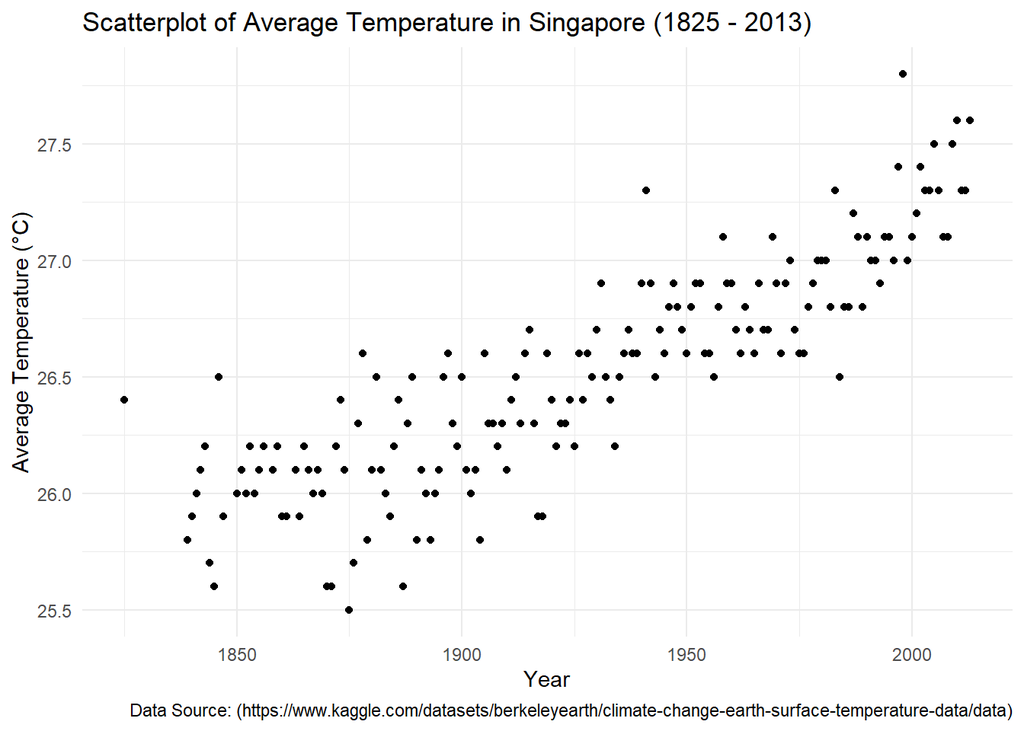

```r
# Generate the scatter plot
scatter_plot <- ggplot(yearly_data, aes(x = Year, y = AvgTemperature)) +
  geom_point() +
  labs(
    title = "Scatterplot of Average Temperature in Singapore (1825 - 2013)",
    x = "Year",
    y = "Average Temperature (°C)",
    caption = "Data Source: (https://www.kaggle.com/datasets/berkeleyearth/climate-change-earth-surface-temperature-data/data)"
  ) +
  theme_minimal()

# Print the scatter plot
print(scatter_plot)
```

## 2.3 Improving the Scatterplot with Transparency and Jittering

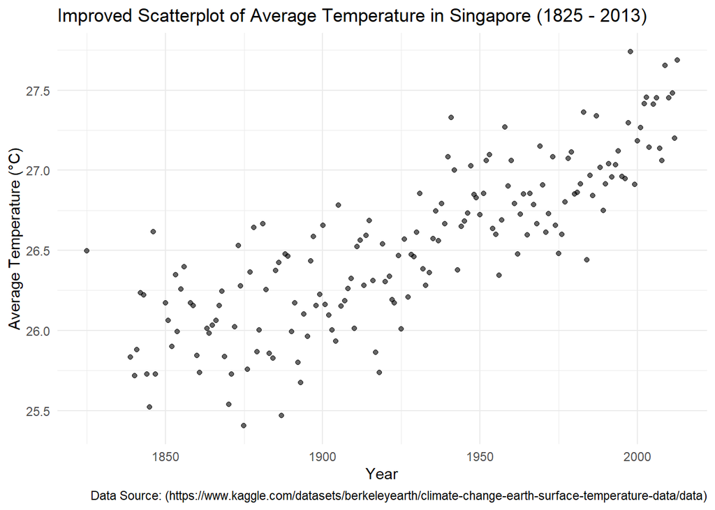

```r
improved_scatter_plot <- ggplot(yearly_data, aes(x = Year, y = AvgTemperature)) +
  geom_point(alpha = 0.6, position = position_jitter(width = 0.2, height = 0.2)) +
  labs(
    title = "Improved Scatterplot of Average Temperature in Singapore (1825 - 2013)",
    x = "Year",
    y = "Average Temperature (°C)",
    caption = "Data Source: (https://www.kaggle.com/datasets/berkeleyearth/climate-change-earth-surface-temperature-data/data)"
  ) +
  theme_minimal()

# Print the improved scatter plot
print(improved_scatter_plot)
```

## 2.4 Adding a Trend Line to the Scatterplot

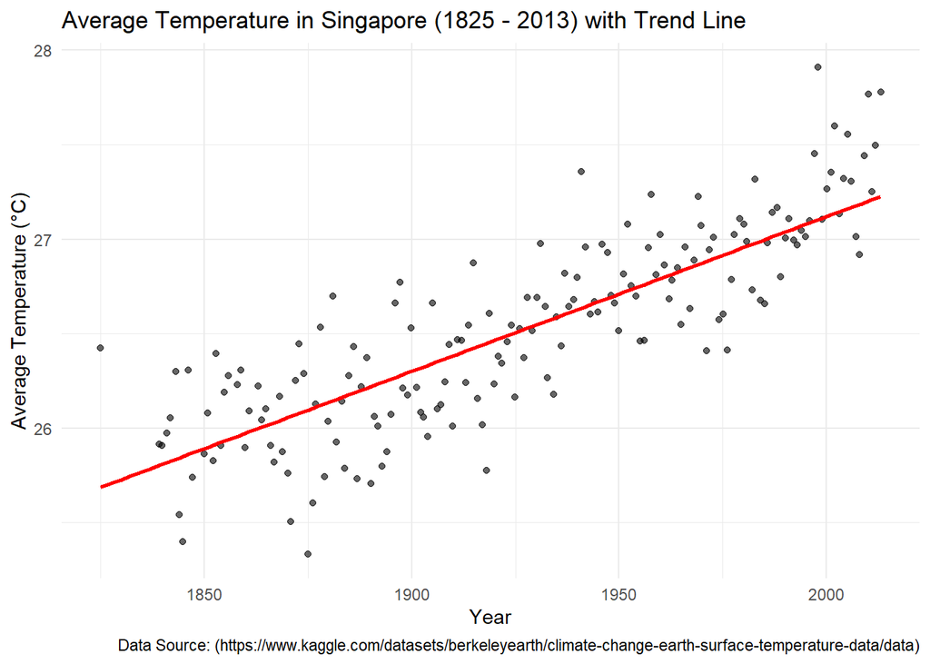

```r
# Scatter plot with transparency and jittering, and a trend curve
scatter_plot_with_trend <- ggplot(yearly_data, aes(x = Year, y = AvgTemperature)) +
  geom_point(alpha = 0.6, position = position_jitter(width = 0.2, height = 0.2)) +
  geom_smooth(method = "lm", se = FALSE, color = "red") +
  labs(
    title = "Average Temperature in Singapore (1825 - 2013) with Trend Line",
    x = "Year",
    y = "Average Temperature (°C)",
    caption = "Data Source: (https://www.kaggle.com/datasets/berkeleyearth/climate-change-earth-surface-temperature-data/data)"
  ) +
  theme_minimal()
print(scatter_plot_with_trend)
```

### Integrating LOESS curve with Trend Line on Scatterplot

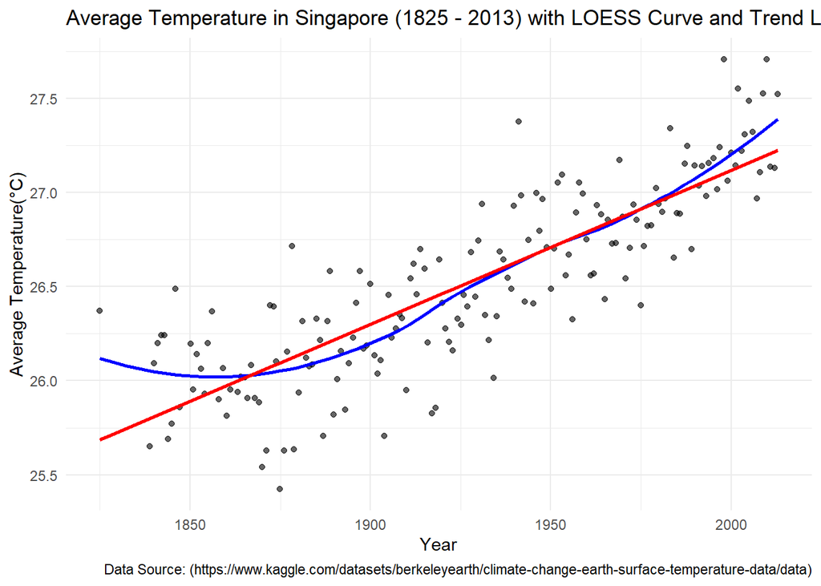

```r
# Scatter plot with transparency and jittering, and a LOESS smoothing curve
scatter_plot_with_loess <- ggplot(yearly_data, aes(x = Year, y = AvgTemperature)) +
  geom_point(alpha = 0.6, position = position_jitter(width = 0.2, height = 0.2)) +
  geom_smooth(method = "loess", se = FALSE, color = "blue") +
  geom_smooth(method = "lm", se = FALSE, color = "red") +
  labs(
    title = "Average Temperature in Singapore (1825 - 2013) with LOESS Curve and Trend Line",
    x = "Year",
    y = "Average Temperature(°C)",
    caption = "Data Source: (https://www.kaggle.com/datasets/berkeleyearth/climate-change-earth-surface-temperature-data/data)"
  ) +
  theme_minimal()
print(scatter_plot_with_loess)
```

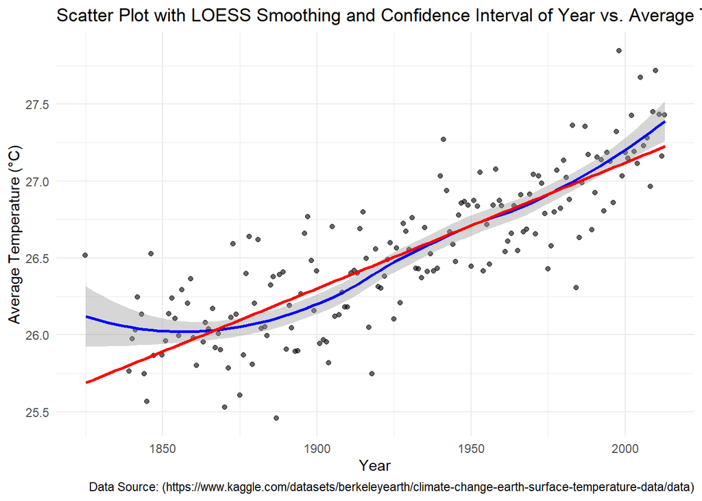

```r
# Scatter plot with transparency and jittering, LOESS smoothing curve, and confidence interval
scatter_plot_with_loess_ci <- ggplot(yearly_data, aes(x = Year, y = AvgTemperature)) +
  geom_point(alpha = 0.6, position = position_jitter(width = 0.2, height = 0.2)) +
  geom_smooth(method = "loess", se = TRUE, color = "blue") +
  geom_smooth(method = "lm", se = FALSE, color = "red") +

  labs(
    title = "Scatter Plot with LOESS Smoothing and Confidence Interval of Year vs. Average Temperature in Singapore",
    x = "Year",
    y = "Average Temperature (°C)",
    caption = "Data Source: (https://www.kaggle.com/datasets/berkeleyearth/climate-change-earth-surface-temperature-data/data)"
  ) +
  theme_minimal()

# Print the scatter plot with LOESS smoothing and confidence interval
print(scatter_plot_with_loess_ci)
```

Based on the scatter plot, it can be observed that the average temperature in Singapore has been increasing over the years. The trend line and LOESS curve further illustrate the general upward trend in temperature over the years.

# Task 3: Visualizing Michelson’s Speed-of-Light Measurements

```r
data(morley)
morley <- as_tibble(morley)
morley
```

```
# A tibble: 100 × 3
    Expt   Run Speed
   <int> <int> <int>
 1     1     1   850
 2     1     2   740
 3     1     3   900
 4     1     4  1070
 5     1     5   930
 6     1     6   850
 7     1     7   950
 8     1     8   980
 9     1     9   980
10     1    10   880
# ℹ 90 more rows
```

## 3.1 Convert Expt Column to Factor

```r
morley <- morley |>
  mutate(Expt = as.factor(Expt))
morley
```

```
# A tibble: 100 × 3
   Expt    Run Speed
   <fct> <int> <int>
 1 1         1   850
 2 1         2   740
 3 1         3   900
 4 1         4  1070
 5 1         5   930
 6 1         6   850
 7 1         7   950
 8 1         8   980
 9 1         9   980
10 1        10   880
# ℹ 90 more rows
```

## 3.2 Plot 1 – Create a Scatter Plot displaying Experiment Number vs. Measured Speeds

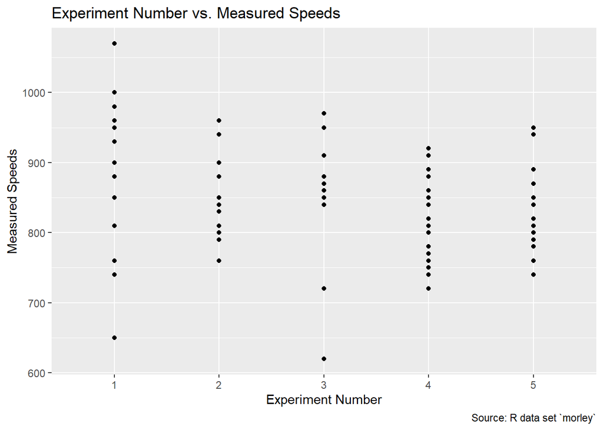

```r
morley |>
  ggplot(aes(x = Expt, y = Speed)) +
  geom_point() +
  labs(title = "Experiment Number vs. Measured Speeds",
       caption = "Source: R data set `morley`",
       x = "Experiment Number",
       y = "Measured Speeds")
```

## 3.3 Plot 2 – Create a Box Plot Measured Speeds with One Box Experiment

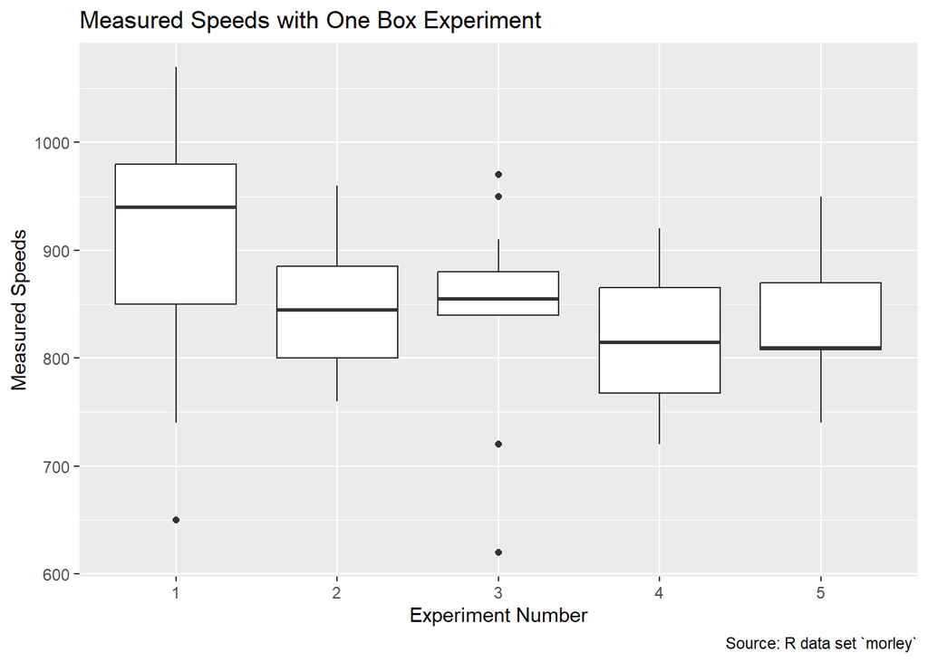

```r
morley |>
  ggplot(aes(x = Expt, y = Speed)) +
  geom_boxplot() +
  labs(title = "Measured Speeds with One Box Experiment",
       caption = "Source: R data set `morley`",
       x = "Experiment Number",
       y = "Measured Speeds")
```

## 3.4 Plot 3 – Add a Violin Plot in Plot 2

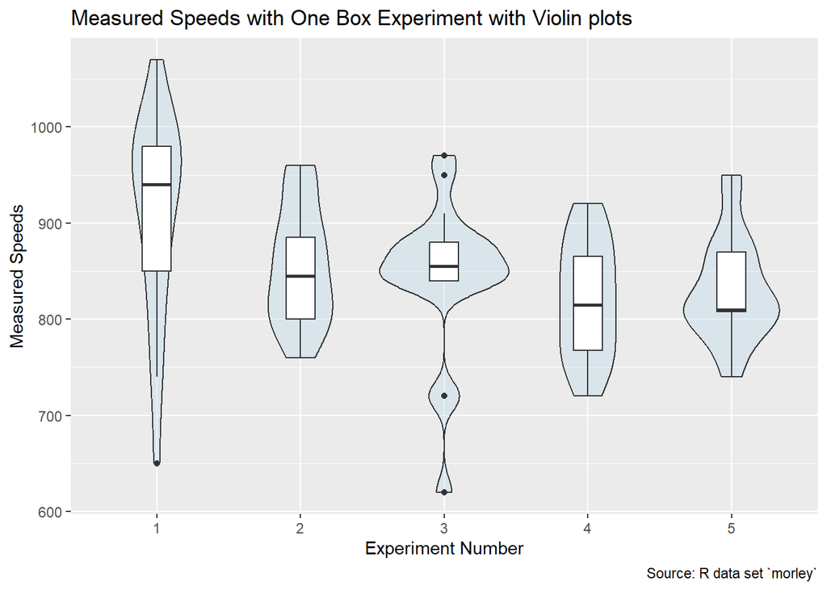

```r
morley |>
  ggplot(aes(x = Expt, y = Speed)) +
  geom_violin(fill = "lightblue", alpha = 0.3) +
  geom_boxplot(width = 0.2) +
  labs(title = "Measured Speeds with One Box Experiment with Violin plots",
       caption = "Source: R data set `morley`",
       x = "Experiment Number",
       y = "Measured Speeds")
```

## 3.5 Plot 4 – Create a Faceted Plot Containing 5 Histograms

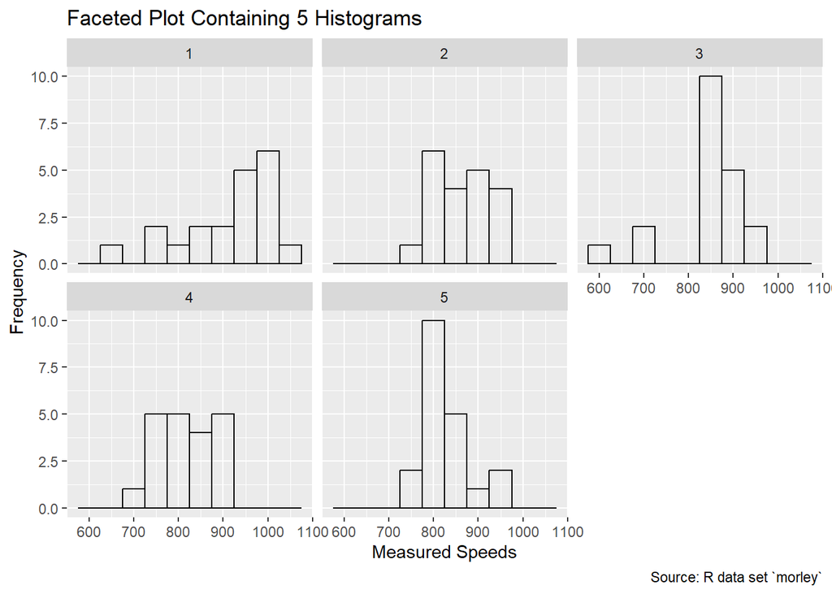

```r
morley |>
  ggplot(aes(x = Speed)) +
  geom_histogram(bins = 10, fill = NA, color="black") +
  facet_wrap(~Expt) +
  labs(title = "Faceted Plot Containing 5 Histograms",
       caption = "Source: R data set `morley`",
       x = "Measured Speeds",
       y = "Frequency")
```

## 3.6 Discuss Your Choice Among the 4 Visualization Plots

We choose Plot 3 - Violin Plot + Box Plot. Since violin plot can be used for grouped data, this plot is chosen because it provides a good visualization of the distribution of the measured speeds across the different experiments. The box plot provides a summary of the distribution of the measured speeds, while the violin plot provides a more detailed view of the distribution of the measured speeds. The combination of the two plots allows us to see the spread of the measured speeds and the distribution of the measured speeds within each experiment.